# Project 1: Conditioning Our Expectations

Sam Unger

September 19, 2019

#### This report investigates some of the song lyrics that really set genres apart from one another.

Here, we process the raw textual data for our data analysis. (Feel free to skip down to where we load the processed data!)

“lyrics.csv” is a filtered corpus of 380,000+ song lyrics from from MetroLyrics. You can read more about it on [Kaggle](https://www.kaggle.com/gyani95/380000-lyrics-from-metrolyrics).

“artists.csv” provides the background information of all the artists. These information are scraped from [LyricsFreak](https://www.lyricsfreak.com/).

### Step 0 - Load all the required libraries

From the packages’ descriptions:

- `tm` is a framework for text mining applications within R;
- `data.table` is a package for fast aggregation of large data
- `tidytext` allows text mining using ‘dplyr’, ‘ggplot2’, and other tidy tools;
- `tidyverse` is an opinionated collection of R packages designed for data science. All packages share an underlying design philosophy, grammar, and data structures;
- `DT` provides an R interface to the JavaScript library DataTables.

```r
library(tm)
library(data.table)
library(tidytext)
library(tidyverse)
library(DT)
```

### Step 1 - Load the data to be cleaned and processed

```r
# load lyrics data
load('../data/lyrics.RData')
```

### Step 2 - Preliminary cleaning of text

We clean the text by converting all the letters to the lower case, and removing punctuation, numbers, empty words and extra white space.

```r
# Long runtime here! ~30-40 minutes to stem
# function for removimg leading and trailing whitespace from character strings
leadingWhitespace <- content_transformer(function(x) str_trim(x, side = "both"))
# remove stop words
data("stop_words")
word <- c("lot", "today", "months", "month", "wanna", "wouldnt", "wasnt", "ha", "na", "ooh", "da",
        "gonna", "im", "dont", "aint", "wont", "yeah", "la", "oi", "nigga", "fuck",
          "hey", "year", "years", "last", "past", "feel")
stop_words <- c(stop_words$word, word)
# clean the data and make a corpus
corpus <- VCorpus(VectorSource(dt_lyrics$lyrics))%>%
  tm_map(content_transformer(tolower))%>%
  tm_map(removePunctuation)%>%
  tm_map(removeWords, character(0))%>%
  tm_map(removeWords, stop_words)%>%
  tm_map(removeNumbers)%>%
  tm_map(stripWhitespace)%>%
  tm_map(leadingWhitespace)
```

### Step 3 - Stemming words and converting tm object to tidy object

Stemming reduces a word to its word *stem*. We stem the words here and then convert the “tm” object to a “tidy” object for much faster processing.

```r
stemmed <- tm_map(corpus, stemDocument) %>%
  tidy() %>%
  select(text)
```

### Step 4 - Creating tidy format of the dictionary to be used for completing stems

We also need a dictionary to look up the words corresponding to the stems.

```r
dict <- tidy(corpus) %>%
  select(text) %>%
  unnest_tokens(dictionary, text)
```

### Step 5 - Combining stems and dictionary into the same tibble

Here we combine the stems and the dictionary into the same “tidy” object.

```r
completed <- stemmed %>%
  mutate(id = row_number()) %>%
  unnest_tokens(stems, text) %>%
  bind_cols(dict)
```

### Step 6 - Stem completion

Lastly, we complete the stems by picking the corresponding word with the highest frequency.

```r
completed <- completed %>%
  group_by(stems) %>%
  count(dictionary) %>%
  mutate(word = dictionary[which.max(n)]) %>%
  ungroup() %>%
  select(stems, word) %>%
  distinct() %>%
  right_join(completed) %>%
  select(-stems)
```

### Step 7 - Pasting stem completed individual words into their respective lyrics

We want our processed words to resemble the structure of the original lyrics. So we paste the words together to form processed lyrics.

```r
completed <- completed %>%
  group_by(id) %>%
  summarise(stemmedwords= str_c(word, collapse = " ")) %>%
  ungroup()
```

### Step 8 - Keeping a track of the processed lyrics with their own ID

```r
dt_lyrics <- dt_lyrics %>%
  mutate(id = row_number()) %>%
  inner_join(completed)
```

```r
save(dt_lyrics, file="../output/processed_lyrics.RData")
```

The final processed data is ready to be used for any kind of analysis.

Now we can use some functions I’ve coded up (see lib folder for details) to measure word popularity across genres and even calculate some conditional probabilities!

## Idea:

What are the some of the most unique words in each genre? How few words do we need to specify a genre with high certainty?

The provided starter Shiny code showed us the most *popular* words in each genre. I, for one, was kind of disappointed with the results, because they were all so similar! In my head, although I didn’t realize it at first, what I was hoping to see were the words most *unique* to each genre. So that’s what I tried to figure out with this project.

```r
load('../output/processed_lyrics.RData')
```

The Shiny code example’s most frequent words in each genre were a good place to start. But for this project, we want to be more careful, by seeing the words that don’t just appear frequently in a genre, but in the most songs of that genre; and, in particular, as few appearances in other genres as possible.

### Function 1: The Filter

```r
# filter_by_word takes in a df and word and returns only the parts of the df
# which correspond to the stemmedwords column with the word in it

filter_by_word <- function(df,word){
  matches <- grep(pattern=word,df$stemmedwords)
  return(df[matches,])
}
```

Now that we have our filter, we can starting counting all these songs with particular words in them!

### Function 2: The Counter

```r
# RawCounts counts number of songs in each genre which contain given word
# For multiple words, RawCounts tracks each word's counts as well as joint counts

RawCounts <- function(words_of_interest){
  # useful initial values
  WoI <- words_of_interest
  num_WoI <- length(WoI)
  num_songs_by_genre <- summary(factor(dt_lyrics$genre))
  genres <- names(num_songs_by_genre)
  num_genres <- length(genres)

  # start with all songs
  lyrics_by_genre <- split(dt_lyrics,f=dt_lyrics$genre) # doesn't change in loop
  matches_by_genre <- lyrics_by_genre # filters successively by matched WoI in loop

  # initiate storage variables for counts tracked in loop
  WoI_ct_by_genre <- matrix(NA,ncol=num_genres,nrow = num_WoI) # counts for each WoI
  colnames(WoI_ct_by_genre) <- genres ; rownames(WoI_ct_by_genre) <- WoI
  joint_ct_by_genre <- matrix(NA,ncol=num_genres,nrow = num_WoI) # joint counts
  colnames(joint_ct_by_genre) <- genres ; rownames(joint_ct_by_genre) <- WoI

  # loop; fills two matrices with song counts corresponding to word matching
  for (W in WoI){
    temp_matches_by_genre <- sapply(lyrics_by_genre,filter_by_word,word=W,simplify=F)
    matches_by_genre <- sapply(matches_by_genre, filter_by_word,word=W,simplify=F)
    WoI_ct_by_genre[W,] <- sapply(temp_matches_by_genre,nrow,USE.NAMES = F)
    joint_ct_by_genre[W,] <- sapply(matches_by_genre,nrow,USE.NAMES = F)
  }

  return(list("Individual Counts"=WoI_ct_by_genre,"Joint Counts"=joint_ct_by_genre,
              "Number of Songs by Genre"=num_songs_by_genre))
}
```

### Function 3: The Probabiliter

```r
# Probabilities conditioned on genre!

CondProbs <- function(Raw_Counts){
  # Extract data from RawCounts function output
  individual_counts <- Raw_Counts$"Individual Counts"
  joint_counts <- Raw_Counts$"Joint Counts"
  num_songs_by_genre <- Raw_Counts$"Number of Songs by Genre"

  # Divide words' song counts by genres' song counts to standardize (per song rate)
  word_rates_by_genre <- individual_counts / num_songs_by_genre
  joint_rates_by_genre <- joint_counts / num_songs_by_genre


  # Important: P(genre|word)
  prob_genre_by_word <- word_rates_by_genre / rowSums(word_rates_by_genre)
  joint_prob_genre_by_word <- joint_rates_by_genre / rowSums(joint_rates_by_genre)

  return(list("Individual Conditional Probs"=prob_genre_by_word,
              "Joint Conditional Probs"=joint_prob_genre_by_word,
              "Number of Songs by Genre"=num_songs_by_genre))
}
```

### Function 4: The Plotter

```r
# Plots joint conditional probabilities from CondProbs

BarPlots <- function(Cond_Probs){
  # Take in joint conditional probabilites from CondProbs
  joint_cond_probs  <- Cond_Probs$"Joint Conditional Probs"

  # Retrieve info for sorting and labeling
  words <- rownames(joint_cond_probs)
  num_words <- length(words)
  last_word <- words[num_words]
  topfive <- order(joint_cond_probs[last_word,],decreasing = T)[1:5]

  # Plot
  barplot(joint_cond_probs[last_word,topfive],
          main = paste(words,sep = ','),
          ylab = "P(Genre|Words)",
          ylim = c(0,1),
          col = c("blue","green","red")[num_words%%3+1]) # color variation
}
```

### See it all work!

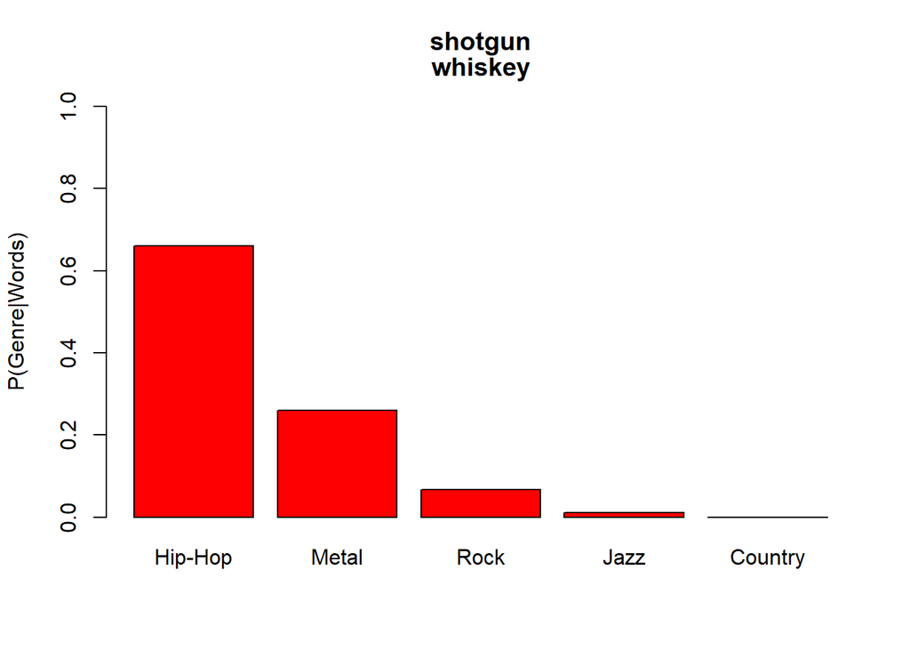

```r
demo1words <- c("shotgun","whiskey")
demo1rawcounts <- RawCounts(demo1words)
demo1condprobs <- CondProbs(demo1rawcounts)
BarPlots(demo1condprobs)
```

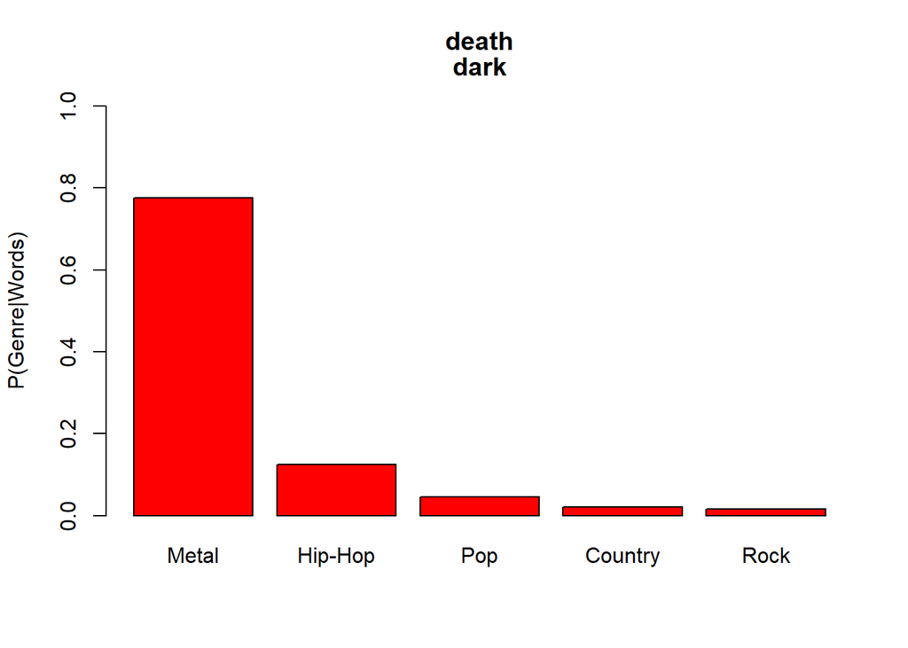

```r
demo2words <- c("death","dark")
demo2rawcounts <- RawCounts(demo2words)
demo2condprobs <- CondProbs(demo2rawcounts)
BarPlots(demo2condprobs)
```

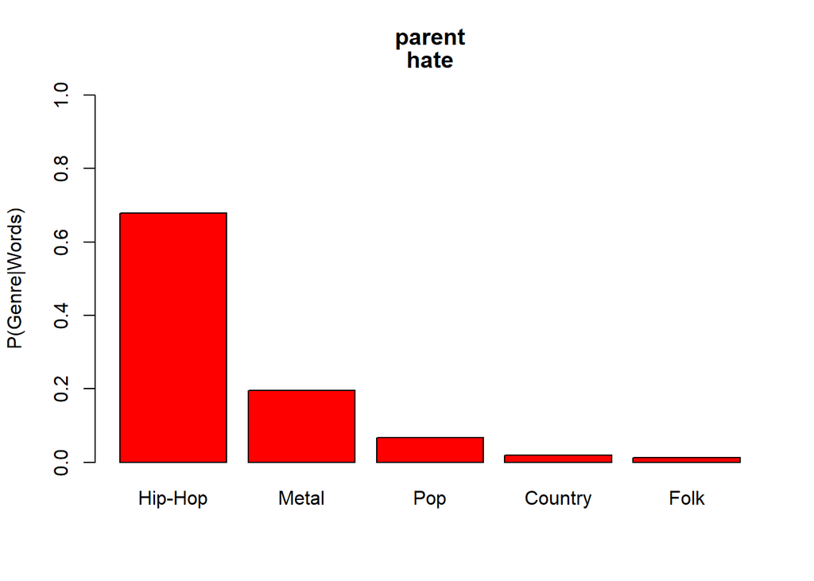

```r
demo3words <- c("parent","hate")
demo3rawcounts <- RawCounts(demo3words)
demo3condprobs <- CondProbs(demo3rawcounts)
BarPlots(demo3condprobs)
```

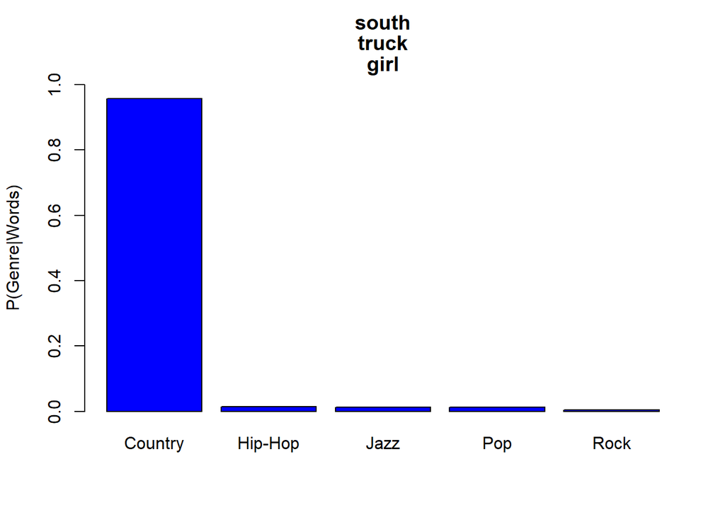

```r
demo4words <- c("south","truck","girl")
demo4rawcounts <- RawCounts(demo4words)
demo4condprobs <- CondProbs(demo4rawcounts)
BarPlots(demo4condprobs)
```

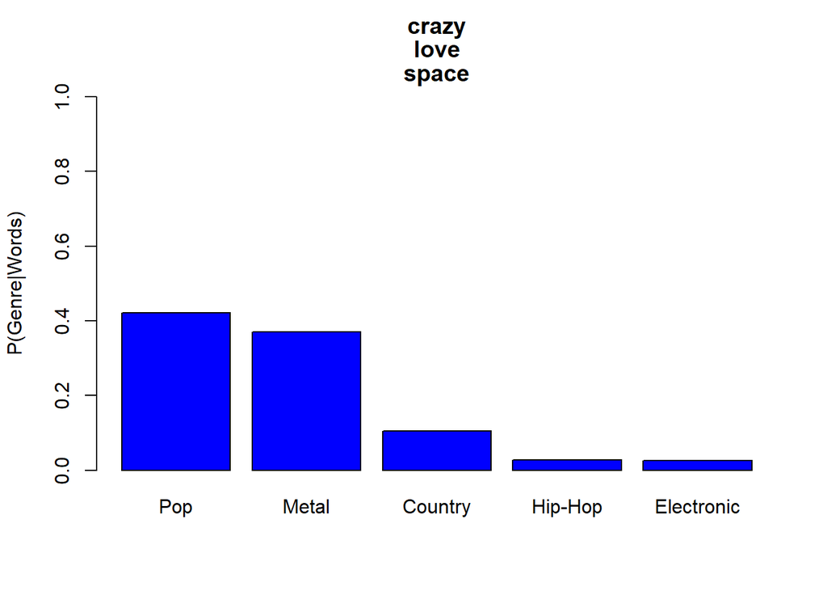

```r
demo5words <- c("crazy","love","space")
demo5rawcounts <- RawCounts(demo5words)
demo5condprobs <- CondProbs(demo5rawcounts)
BarPlots(demo5condprobs)
```